# FinalProject

```r
# perform backward step-wise regression

backward<-stepAIC (full, direction='backward')
```

```
## Start:  AIC=-38.83
## LeagueIndex ~ Age + HoursPerWeek + TotalHours + APM + SelectByHotkeys +
##     AssignToHotkeys + UniqueHotkeys + MinimapAttacks + MinimapRightClicks +
##     NumberOfPACs + GapBetweenPACs + ActionLatency + ActionsInPAC +
##     TotalMapExplored + WorkersMade + UniqueUnitsMade + ComplexUnitsMade +
##     ComplexAbilitiesUsed
##
##                        Df Sum of Sq    RSS     AIC
## - ComplexAbilitiesUsed  1     0.041 2590.3 -40.788
## <none>                              2590.3 -38.831
## - ActionsInPAC          1     2.014 2592.3 -38.758
## - UniqueUnitsMade       1     2.465 2592.7 -38.295
## - ComplexUnitsMade      1     2.481 2592.8 -38.278
## - MinimapRightClicks    1     3.190 2593.5 -37.550
## - TotalMapExplored      1     4.968 2595.2 -35.723
## - APM                   1     5.348 2595.6 -35.332
## - NumberOfPACs          1     9.221 2599.5 -31.357
## - HoursPerWeek          1     9.339 2599.6 -31.236
## - Age                   1     9.829 2600.1 -30.734
## - UniqueHotkeys         1    11.578 2601.8 -28.940
## - WorkersMade           1    23.740 2614.0 -16.508
## - TotalHours            1    25.964 2616.2 -14.240
## - SelectByHotkeys       1    26.781 2617.1 -13.408
## - GapBetweenPACs        1    35.894 2626.2  -4.141
## - AssignToHotkeys       1    68.410 2658.7  28.666
## - MinimapAttacks        1    72.348 2662.6  32.612
## - ActionLatency         1   132.439 2722.7  92.110
##
## Step:  AIC=-40.79
## LeagueIndex ~ Age + HoursPerWeek + TotalHours + APM + SelectByHotkeys +
##     AssignToHotkeys + UniqueHotkeys + MinimapAttacks + MinimapRightClicks +
##     NumberOfPACs + GapBetweenPACs + ActionLatency + ActionsInPAC +
##     TotalMapExplored + WorkersMade + UniqueUnitsMade + ComplexUnitsMade
##
##                      Df Sum of Sq    RSS     AIC
## <none>                            2590.3 -40.788
## - ActionsInPAC        1     1.978 2592.3 -40.753
## - UniqueUnitsMade     1     2.517 2592.8 -40.199
## - ComplexUnitsMade    1     3.013 2593.3 -39.689
## - MinimapRightClicks  1     3.184 2593.5 -39.513
## - TotalMapExplored    1     4.994 2595.3 -37.653
## - APM                 1     5.306 2595.6 -37.332
## - NumberOfPACs        1     9.180 2599.5 -33.356
## - HoursPerWeek        1     9.318 2599.6 -33.215
## - Age                 1     9.832 2600.1 -32.688
## - UniqueHotkeys       1    11.606 2601.9 -30.870
## - WorkersMade         1    23.857 2614.2 -18.346
## - TotalHours          1    25.938 2616.2 -16.225
## - SelectByHotkeys     1    26.783 2617.1 -15.364
## - GapBetweenPACs      1    35.969 2626.3  -6.023
## - AssignToHotkeys     1    68.455 2658.8  26.752
## - MinimapAttacks      1    72.371 2662.7  30.676
## - ActionLatency       1   132.600 2722.9  90.308
```

```r
backward$anova
```

```
## Stepwise Model Path
## Analysis of Deviance Table
##
## Initial Model:
## LeagueIndex ~ Age + HoursPerWeek + TotalHours + APM + SelectByHotkeys +
##     AssignToHotkeys + UniqueHotkeys + MinimapAttacks + MinimapRightClicks +
##     NumberOfPACs + GapBetweenPACs + ActionLatency + ActionsInPAC +
##     TotalMapExplored + WorkersMade + UniqueUnitsMade + ComplexUnitsMade +
##     ComplexAbilitiesUsed
##
## Final Model:
## LeagueIndex ~ Age + HoursPerWeek + TotalHours + APM + SelectByHotkeys +
##     AssignToHotkeys + UniqueHotkeys + MinimapAttacks + MinimapRightClicks +
##     NumberOfPACs + GapBetweenPACs + ActionLatency + ActionsInPAC +
##     TotalMapExplored + WorkersMade + UniqueUnitsMade + ComplexUnitsMade
##
##
##                     Step Df   Deviance Resid. Df Resid. Dev       AIC
## 1                                           2647   2590.266 -38.83087
## 2 - ComplexAbilitiesUsed  1 0.04146782      2648   2590.307 -40.78819
```

```r
summary(backward)
```

```
##
## Call:
## lm(formula = LeagueIndex ~ Age + HoursPerWeek + TotalHours +
##     APM + SelectByHotkeys + AssignToHotkeys + UniqueHotkeys +
##     MinimapAttacks + MinimapRightClicks + NumberOfPACs + GapBetweenPACs +
##     ActionLatency + ActionsInPAC + TotalMapExplored + WorkersMade +
##     UniqueUnitsMade + ComplexUnitsMade, data = Training)
##
## Residuals:
##     Min      1Q  Median      3Q     Max
## -4.4423 -0.6598  0.0499  0.6764  2.9508
##
## Coefficients:
##                      Estimate Std. Error t value Pr(>|t|)
## (Intercept)         4.959e+00  4.051e-01  12.241  < 2e-16 ***
## Age                 1.570e-02  4.953e-03   3.170 0.001540 **
## HoursPerWeek        5.263e-03  1.705e-03   3.086 0.002047 **
## TotalHours          1.125e-04  2.185e-05   5.149 2.81e-07 ***
## APM                -5.651e-03  2.426e-03  -2.329 0.019931 *
## SelectByHotkeys     7.384e+01  1.411e+01   5.233 1.80e-07 ***
## AssignToHotkeys     9.363e+02  1.119e+02   8.365  < 2e-16 ***
## UniqueHotkeys       3.241e-02  9.409e-03   3.444 0.000581 ***
## MinimapAttacks      1.024e+03  1.190e+02   8.601  < 2e-16 ***
## MinimapRightClicks  1.025e+02  5.679e+01   1.804 0.071325 .
## NumberOfPACs        2.278e+02  7.436e+01   3.063 0.002210 **
## GapBetweenPACs     -1.160e-02  1.913e-03  -6.064 1.52e-09 ***
## ActionLatency      -3.306e-02  2.839e-03 -11.643  < 2e-16 ***
## ActionsInPAC        5.250e-02  3.692e-02   1.422 0.155172
## TotalMapExplored   -7.851e-03  3.475e-03  -2.259 0.023939 *
## WorkersMade         2.083e+02  4.219e+01   4.938 8.36e-07 ***
## UniqueUnitsMade    -2.134e-02  1.331e-02  -1.604 0.108842
## ComplexUnitsMade    3.355e+02  1.912e+02   1.755 0.079372 .
## ---
## Signif. codes:  0 '***' 0.001 '**' 0.01 '*' 0.05 '.' 0.1 ' ' 1
##
## Residual standard error: 0.989 on 2648 degrees of freedom
## Multiple R-squared:  0.5665, Adjusted R-squared:  0.5637
## F-statistic: 203.6 on 17 and 2648 DF,  p-value: < 2.2e-16
```

```r
#Get MAE and MSE
ypred_backward <-predict(object =backward , newdata = Test)
MAE(y_pred = ypred_backward, y_true = Test$LeagueIndex)
```

```
## [1] 0.9332337
```

```r
MSE(y_pred = ypred_backward, y_true = Test$LeagueIndex)
```

```
## [1] 21.1557
```

```r
# perform both step-wise regression
both <- stepAIC (intercept_only, direction='both',scope = formula(full),trace = 0)

# view results of both stepwise regression
both$anova
```

```
## Stepwise Model Path
## Analysis of Deviance Table
##
## Initial Model:
## LeagueIndex ~ 1
##
## Final Model:
## LeagueIndex ~ ActionLatency + SelectByHotkeys + AssignToHotkeys +
##     MinimapAttacks + GapBetweenPACs + TotalHours + WorkersMade +
##     UniqueHotkeys + Age + HoursPerWeek + NumberOfPACs + TotalMapExplored +
##     APM + MinimapRightClicks + ActionsInPAC
##
##
##                    Step Df    Deviance Resid. Df Resid. Dev         AIC
## 1                                           2665   5975.467 2153.683527
## 2       + ActionLatency  1 2665.381630      2664   3310.086  580.908723
## 3     + SelectByHotkeys  1  314.508873      2663   2995.577  316.742562
## 4     + AssignToHotkeys  1  138.179275      2662   2857.398  192.839258
## 5      + MinimapAttacks  1  109.034556      2661   2748.363   91.116387
## 6      + GapBetweenPACs  1   45.348016      2660   2703.015   48.760410
## 7          + TotalHours  1   35.358535      2659   2667.656   15.655967
## 8         + WorkersMade  1   23.598215      2658   2644.058   -6.032525
## 9       + UniqueHotkeys  1   12.393992      2657   2631.664  -16.558749
## 10                + Age  1    6.929534      2656   2624.735  -21.587952
## 11       + HoursPerWeek  1    9.032131      2655   2615.703  -28.777905
## 12       + NumberOfPACs  1    5.683887      2654   2610.019  -32.577390
## 13   + TotalMapExplored  1    7.994305      2653   2602.024  -38.755693
## 14                + APM  1    2.363558      2652   2599.661  -39.178465
## 15 + MinimapRightClicks  1    2.811322      2651   2596.850  -40.063087
## 16       + ActionsInPAC  1    2.230137      2650   2594.619  -40.353593
```

```r
summary(both)
```

```
##
## Call:
## lm(formula = LeagueIndex ~ ActionLatency + SelectByHotkeys +
##     AssignToHotkeys + MinimapAttacks + GapBetweenPACs + TotalHours +
##     WorkersMade + UniqueHotkeys + Age + HoursPerWeek + NumberOfPACs +
##     TotalMapExplored + APM + MinimapRightClicks + ActionsInPAC,
##     data = Training)
##
## Residuals:
##     Min      1Q  Median      3Q     Max
## -4.4660 -0.6609  0.0445  0.6816  2.9518
##
## Coefficients:
##                      Estimate Std. Error t value Pr(>|t|)
## (Intercept)         4.903e+00  4.044e-01  12.125  < 2e-16 ***
## ActionLatency      -3.353e-02  2.831e-03 -11.843  < 2e-16 ***
## SelectByHotkeys     7.426e+01  1.410e+01   5.266 1.51e-07 ***
## AssignToHotkeys     9.459e+02  1.118e+02   8.462  < 2e-16 ***
## MinimapAttacks      1.013e+03  1.189e+02   8.515  < 2e-16 ***
## GapBetweenPACs     -1.134e-02  1.909e-03  -5.938 3.27e-09 ***
## TotalHours          1.122e-04  2.186e-05   5.135 3.03e-07 ***
## WorkersMade         2.149e+02  4.180e+01   5.142 2.91e-07 ***
## UniqueHotkeys       3.087e-02  9.365e-03   3.296 0.000993 ***
## Age                 1.513e-02  4.947e-03   3.059 0.002240 **
## HoursPerWeek        5.277e-03  1.706e-03   3.094 0.001998 **
## NumberOfPACs        2.218e+02  7.412e+01   2.993 0.002788 **
## TotalMapExplored   -9.082e-03  3.061e-03  -2.967 0.003033 **
## APM                -5.670e-03  2.419e-03  -2.343 0.019178 *
## MinimapRightClicks  9.607e+01  5.664e+01   1.696 0.090017 .
## ActionsInPAC        5.556e-02  3.682e-02   1.509 0.131362
## ---
## Signif. codes:  0 '***' 0.001 '**' 0.01 '*' 0.05 '.' 0.1 ' ' 1
##
## Residual standard error: 0.9895 on 2650 degrees of freedom
## Multiple R-squared:  0.5658, Adjusted R-squared:  0.5633
## F-statistic: 230.2 on 15 and 2650 DF,  p-value: < 2.2e-16
```

```r
# base on the result ,we can see the multiple variables should including

#Get MAE and MSE
ypred_both <-predict(object =both , newdata = Test)
MAE(y_pred = ypred_both, y_true = Test$LeagueIndex)
```

```
## [1] 0.9335465
```

```r
MSE(y_pred = ypred_both, y_true = Test$LeagueIndex)
```

```
## [1] 21.06631
```

> Base on the model we get,we can see the value for Multiple R-squared, Adjusted R-squared,p-value, Residual standard error,MAE,MSE. But We can’t judage if this model is the best or not.So we need compare with another model we select.

```r
# build one model

manualModel<-lm(formula = LeagueIndex ~ Age+HoursPerWeek + TotalHours + APM + SelectByHotkeys + AssignToHotkeys, data = Training)

summary(manualModel)
```

```
##
## Call:
## lm(formula = LeagueIndex ~ Age + HoursPerWeek + TotalHours +
##     APM + SelectByHotkeys + AssignToHotkeys, data = Training)
##
## Residuals:
##     Min      1Q  Median      3Q     Max
## -4.1637 -0.7365  0.0476  0.7794  3.3845
##
## Coefficients:
##                   Estimate Std. Error t value Pr(>|t|)
## (Intercept)      1.169e+00  1.490e-01   7.850 6.00e-15 ***
## Age              1.212e-02  5.318e-03   2.279  0.02274 *
## HoursPerWeek     5.473e-03  1.860e-03   2.942  0.00329 **
## TotalHours       1.432e-04  2.386e-05   6.002 2.22e-09 ***
## APM              1.902e-02  8.220e-04  23.138  < 2e-16 ***
## SelectByHotkeys -5.596e+01  7.319e+00  -7.646 2.88e-14 ***
## AssignToHotkeys  1.612e+03  1.142e+02  14.118  < 2e-16 ***
## ---
## Signif. codes:  0 '***' 0.001 '**' 0.01 '*' 0.05 '.' 0.1 ' ' 1
##
## Residual standard error: 1.084 on 2659 degrees of freedom
## Multiple R-squared:  0.4766, Adjusted R-squared:  0.4755
## F-statistic: 403.6 on 6 and 2659 DF,  p-value: < 2.2e-16
```

```r
#Get MAE and MSE
ypred_manual <-predict(object =manualModel,newdata = Test)
MAE(y_pred = ypred_manual, y_true = Test$LeagueIndex)
```

```
## [1] 1.042363
```

```r
MSE(y_pred = ypred_manual, y_true = Test$LeagueIndex)
```

```
## [1] 33.90225
```

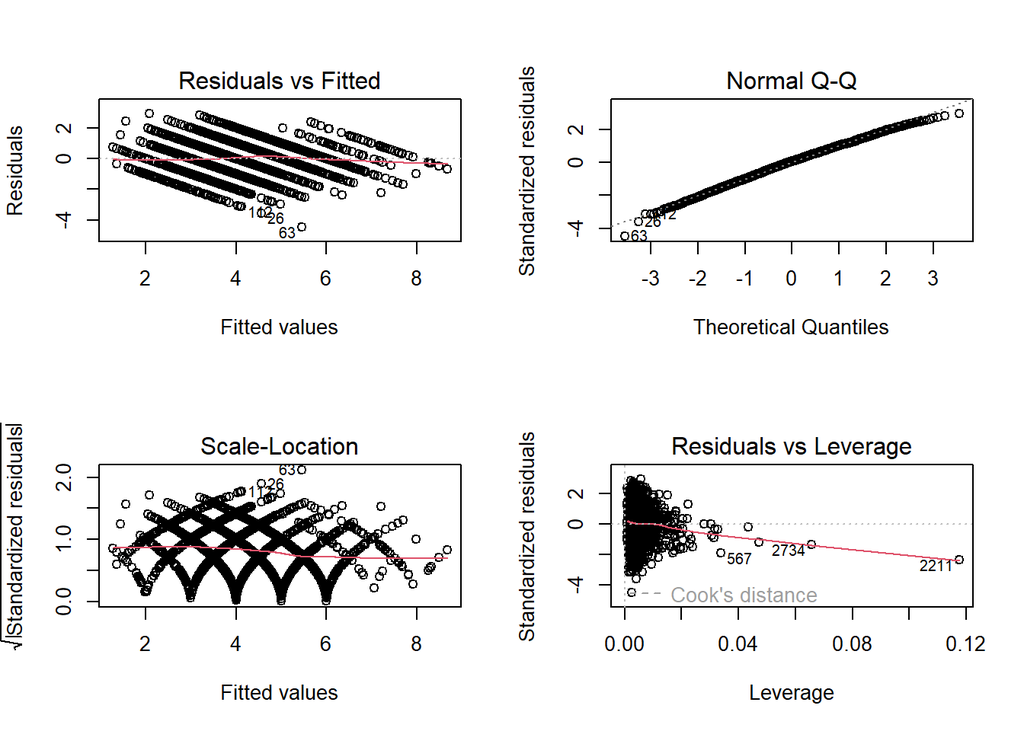

```r
IndexModel<-lm(formula = LeagueIndex ~ ActionLatency + AssignToHotkeys +MinimapAttacks + GapBetweenPACs + WorkersMade + SelectByHotkeys +UniqueHotkeys + HoursPerWeek + NumberOfPACs + TotalMapExplored +Age , data = Training)

par(mfrow=c(2,2))
plot(IndexModel)
```

> By assessing model fit,the previous Model which takes LeagueIndex as reponse seems don’t fit very well.Multiple R-squared and Adjusted R-squared are not very close to 1.We know R2 measures the proportion of variability in Y that can be explained using X.In general,it’s better to close to 1.

> How about take APM as response? The previous Linear Model’s response is LeagueIndex,it is better to consider as Categorical attribute.

```r
# choose APM as response **BY Ming**

intercept_onlyAPM <- lm(APM ~ 1, data=Training)
# Create a full model
fullAPM <- lm(APM~., data=Training)

# perform forward step-wise regression
forwardAPM<-stepAIC (intercept_onlyAPM, direction='forward',scope = formula(fullAPM))
```

```
## Start:  AIC=21012.2
## APM ~ 1
##
##                        Df Sum of Sq     RSS   AIC
## + SelectByHotkeys       1   5028703 2025475 17688
## + ActionLatency         1   3841687 3212491 18917
## + LeagueIndex           1   2950706 4103471 19570
## + NumberOfPACs          1   2806794 4247383 19662
## + AssignToHotkeys       1   2367881 4686296 19924
## + GapBetweenPACs        1   2343374 4710804 19938
## + ActionsInPAC          1   1029321 6024856 20594
## + UniqueHotkeys         1    904634 6149544 20648
## + WorkersMade           1    793238 6260939 20696
## + MinimapRightClicks    1    749821 6304356 20715
## + MinimapAttacks        1    504973 6549204 20816
## + TotalHours            1    332496 6721682 20886
## + TotalMapExplored      1    313375 6740802 20893
## + HoursPerWeek          1    308012 6746165 20895
## + Age                   1    248995 6805183 20918
## + ComplexUnitsMade      1    101035 6953142 20976
## + ComplexAbilitiesUsed  1     96940 6957238 20977
## + UniqueUnitsMade       1     60936 6993241 20991
## <none>                              7054178 21012
##
## Step:  AIC=17687.53
## APM ~ SelectByHotkeys
##
##                        Df Sum of Sq     RSS   AIC
## + ActionLatency         1   1205669  819805 15278
## + GapBetweenPACs        1    768562 1256913 16418
## + NumberOfPACs          1    760100 1265374 16435
## + LeagueIndex           1    486988 1538486 16956
## + ActionsInPAC          1    446593 1578882 17026
## + WorkersMade           1    391389 1634085 17117
## + MinimapRightClicks    1    287276 1738199 17282
## + AssignToHotkeys       1    195046 1830429 17420
## + TotalMapExplored      1    147802 1877673 17488
## + UniqueHotkeys         1     76048 1949427 17588
## + MinimapAttacks        1     69786 1955689 17596
## + UniqueUnitsMade       1     64825 1960649 17603
```

[output cut: 191 more lines]

```
## + ComplexUnitsMade  1     8.263 165082 11026
##
## Step:  AIC=11023.25
## APM ~ SelectByHotkeys + ActionLatency + ActionsInPAC + NumberOfPACs +
##     MinimapRightClicks + WorkersMade + ComplexAbilitiesUsed +
##     Age + MinimapAttacks + LeagueIndex + UniqueUnitsMade + GapBetweenPACs
##
##                    Df Sum of Sq    RSS   AIC
## <none>                          164939 11023
## + TotalMapExplored  1    98.387 164841 11024
## + HoursPerWeek      1    79.518 164860 11024
## + UniqueHotkeys     1    73.292 164866 11024
## + TotalHours        1    46.645 164893 11024
## + AssignToHotkeys   1    27.659 164912 11025
## + ComplexUnitsMade  1    13.176 164926 11025
```

```r
forwardAPM$anova
```

```
## Stepwise Model Path
## Analysis of Deviance Table
##
## Initial Model:
## APM ~ 1
##
## Final Model:
## APM ~ SelectByHotkeys + ActionLatency + ActionsInPAC + NumberOfPACs +
##     MinimapRightClicks + WorkersMade + ComplexAbilitiesUsed +
##     Age + MinimapAttacks + LeagueIndex + UniqueUnitsMade + GapBetweenPACs
##
##
##                      Step Df     Deviance Resid. Df Resid. Dev      AIC
## 1                                              2665  7054177.5 21012.20
## 2       + SelectByHotkeys  1 5028702.8646      2664  2025474.6 17687.53
## 3         + ActionLatency  1 1205669.1784      2663   819805.5 15278.15
## 4          + ActionsInPAC  1  381315.0654      2662   438490.4 13611.95
## 5          + NumberOfPACs  1  259468.7691      2661   179021.6 11225.67
## 6    + MinimapRightClicks  1    5578.2594      2660   173443.4 11143.28
## 7           + WorkersMade  1    4787.5163      2659   168655.9 11070.65
## 8  + ComplexAbilitiesUsed  1    2268.4371      2658   166387.4 11036.55
## 9                   + Age  1     403.4368      2657   165984.0 11032.08
## 10       + MinimapAttacks  1     360.9546      2656   165623.0 11028.27
## 11          + LeagueIndex  1     299.7254      2655   165323.3 11025.45
## 12      + UniqueUnitsMade  1     233.4322      2654   165089.9 11023.68
## 13       + GapBetweenPACs  1     150.4784      2653   164939.4 11023.25
```

```r
summary(forwardAPM)
```

```
##
## Call:
## lm(formula = APM ~ SelectByHotkeys + ActionLatency + ActionsInPAC +
##     NumberOfPACs + MinimapRightClicks + WorkersMade + ComplexAbilitiesUsed +
##     Age + MinimapAttacks + LeagueIndex + UniqueUnitsMade + GapBetweenPACs,
##     data = Training)
##
## Residuals:
##      Min       1Q   Median       3Q      Max
## -119.932   -3.310    0.378    3.939   45.274
##
## Coefficients:
##                        Estimate Std. Error t value Pr(>|t|)
## (Intercept)          -3.367e+01  3.250e+00 -10.361  < 2e-16 ***
## SelectByHotkeys       5.523e+03  3.417e+01 161.657  < 2e-16 ***
## ActionLatency        -2.738e-01  2.260e-02 -12.119  < 2e-16 ***
## ActionsInPAC          1.283e+01  1.577e-01  81.350  < 2e-16 ***
## NumberOfPACs          2.244e+04  3.928e+02  57.138  < 2e-16 ***
## MinimapRightClicks    3.935e+03  4.453e+02   8.838  < 2e-16 ***
## WorkersMade           3.060e+03  3.295e+02   9.284  < 2e-16 ***
## ComplexAbilitiesUsed -3.156e+03  6.139e+02  -5.140 2.94e-07 ***
## Age                  -9.861e-02  3.871e-02  -2.547   0.0109 *
## MinimapAttacks        2.671e+03  9.531e+02   2.803   0.0051 **
## LeagueIndex          -3.715e-01  1.507e-01  -2.466   0.0137 *
## UniqueUnitsMade      -1.700e-01  9.248e-02  -1.839   0.0661 .
## GapBetweenPACs       -2.328e-02  1.496e-02  -1.556   0.1199
## ---
## Signif. codes:  0 '***' 0.001 '**' 0.01 '*' 0.05 '.' 0.1 ' ' 1
##
## Residual standard error: 7.885 on 2653 degrees of freedom
## Multiple R-squared:  0.9766, Adjusted R-squared:  0.9765
## F-statistic:  9234 on 12 and 2653 DF,  p-value: < 2.2e-16
```

```r
#Get MAE,MSE
ypred_forwardAPM <-predict(object =forwardAPM , newdata = Test)
MAE(y_pred = ypred_forwardAPM, y_true = Test$APM)
```

```
## [1] 5.116375
```

```r
MSE(y_pred = ypred_forwardAPM, y_true = Test$APM)
```

```
## [1] 50.48656
```

```r
# perform backward step-wise regression

backwardAPM<-stepAIC (fullAPM, direction='backward')
```

```
## Start:  AIC=11029.16
## APM ~ LeagueIndex + Age + HoursPerWeek + TotalHours + SelectByHotkeys +
##     AssignToHotkeys + UniqueHotkeys + MinimapAttacks + MinimapRightClicks +
##     NumberOfPACs + GapBetweenPACs + ActionLatency + ActionsInPAC +
##     TotalMapExplored + WorkersMade + UniqueUnitsMade + ComplexUnitsMade +
##     ComplexAbilitiesUsed
##
##                        Df Sum of Sq     RSS   AIC
## - ComplexUnitsMade      1        10  164574 11027
## - AssignToHotkeys       1        50  164614 11028
## - TotalHours            1        72  164636 11028
## - TotalMapExplored      1        77  164640 11028
## - UniqueHotkeys         1        89  164652 11029
## - HoursPerWeek          1       111  164674 11029
## <none>                               164563 11029
## - GapBetweenPACs        1       191  164754 11030
## - UniqueUnitsMade       1       334  164898 11033
## - LeagueIndex           1       340  164903 11033
## - MinimapAttacks        1       437  165000 11034
## - Age                   1       511  165075 11035
## - ComplexAbilitiesUsed  1      1266  165829 11048
## - MinimapRightClicks    1      4688  169252 11102
## - WorkersMade           1      5130  169693 11109
## - ActionLatency         1      8943  173506 11168
## - NumberOfPACs          1    189337  353901 13069
## - ActionsInPAC          1    406233  570796 14343
## - SelectByHotkeys       1   1440337 1604900 17099
##
## Step:  AIC=11027.33
## APM ~ LeagueIndex + Age + HoursPerWeek + TotalHours + SelectByHotkeys +
##     AssignToHotkeys + UniqueHotkeys + MinimapAttacks + MinimapRightClicks +
##     NumberOfPACs + GapBetweenPACs + ActionLatency + ActionsInPAC +
##     TotalMapExplored + WorkersMade + UniqueUnitsMade + ComplexAbilitiesUsed
##
##                        Df Sum of Sq     RSS   AIC
## - AssignToHotkeys       1        50  164624 11026
## - TotalHours            1        71  164645 11026
## - TotalMapExplored      1        82  164655 11027
## - UniqueHotkeys         1        88  164662 11027
## - HoursPerWeek          1       111  164684 11027
```

[output cut: 112 more lines]

```
##
##                        Df Sum of Sq     RSS   AIC
## <none>                               164939 11023
## - GapBetweenPACs        1       150  165090 11024
## - UniqueUnitsMade       1       210  165150 11025
## - LeagueIndex           1       378  165317 11027
## - Age                   1       403  165343 11028
## - MinimapAttacks        1       488  165428 11029
## - ComplexAbilitiesUsed  1      1643  166582 11048
## - MinimapRightClicks    1      4856  169796 11099
## - WorkersMade           1      5359  170298 11106
## - ActionLatency         1      9131  174071 11165
## - NumberOfPACs          1    202973  367912 13160
## - ActionsInPAC          1    411439  576378 14357
## - SelectByHotkeys       1   1624718 1789657 17378
```

```r
backwardAPM$anova
```

```
## Stepwise Model Path
## Analysis of Deviance Table
##
## Initial Model:
## APM ~ LeagueIndex + Age + HoursPerWeek + TotalHours + SelectByHotkeys +
##     AssignToHotkeys + UniqueHotkeys + MinimapAttacks + MinimapRightClicks +
##     NumberOfPACs + GapBetweenPACs + ActionLatency + ActionsInPAC +
##     TotalMapExplored + WorkersMade + UniqueUnitsMade + ComplexUnitsMade +
##     ComplexAbilitiesUsed
##
## Final Model:
## APM ~ LeagueIndex + Age + SelectByHotkeys + MinimapAttacks +
##     MinimapRightClicks + NumberOfPACs + GapBetweenPACs + ActionLatency +
##     ActionsInPAC + WorkersMade + UniqueUnitsMade + ComplexAbilitiesUsed
##
##
##                 Step Df Deviance Resid. Df Resid. Dev      AIC
## 1                                     2647   164563.3 11029.16
## 2 - ComplexUnitsMade  1 10.47461      2648   164573.8 11027.33
## 3  - AssignToHotkeys  1 49.78711      2649   164623.6 11026.14
## 4    - UniqueHotkeys  1 63.68054      2650   164687.2 11025.17
## 5       - TotalHours  1 73.25342      2651   164760.5 11024.35
## 6     - HoursPerWeek  1 80.50779      2652   164841.0 11023.66
## 7 - TotalMapExplored  1 98.38691      2653   164939.4 11023.25
```

```r
summary(backwardAPM)
```

```
##
## Call:
## lm(formula = APM ~ LeagueIndex + Age + SelectByHotkeys + MinimapAttacks +
##     MinimapRightClicks + NumberOfPACs + GapBetweenPACs + ActionLatency +
##     ActionsInPAC + WorkersMade + UniqueUnitsMade + ComplexAbilitiesUsed,
##     data = Training)
##
## Residuals:
##      Min       1Q   Median       3Q      Max
## -119.932   -3.310    0.378    3.939   45.274
##
## Coefficients:
##                        Estimate Std. Error t value Pr(>|t|)
## (Intercept)          -3.367e+01  3.250e+00 -10.361  < 2e-16 ***
## LeagueIndex          -3.715e-01  1.507e-01  -2.466   0.0137 *
## Age                  -9.861e-02  3.871e-02  -2.547   0.0109 *
## SelectByHotkeys       5.523e+03  3.417e+01 161.657  < 2e-16 ***
## MinimapAttacks        2.671e+03  9.531e+02   2.803   0.0051 **
## MinimapRightClicks    3.935e+03  4.453e+02   8.838  < 2e-16 ***
## NumberOfPACs          2.244e+04  3.928e+02  57.138  < 2e-16 ***
## GapBetweenPACs       -2.328e-02  1.496e-02  -1.556   0.1199
## ActionLatency        -2.738e-01  2.260e-02 -12.119  < 2e-16 ***
## ActionsInPAC          1.283e+01  1.577e-01  81.350  < 2e-16 ***
## WorkersMade           3.060e+03  3.295e+02   9.284  < 2e-16 ***
## UniqueUnitsMade      -1.700e-01  9.248e-02  -1.839   0.0661 .
## ComplexAbilitiesUsed -3.156e+03  6.139e+02  -5.140 2.94e-07 ***
## ---
## Signif. codes:  0 '***' 0.001 '**' 0.01 '*' 0.05 '.' 0.1 ' ' 1
##
## Residual standard error: 7.885 on 2653 degrees of freedom
## Multiple R-squared:  0.9766, Adjusted R-squared:  0.9765
## F-statistic:  9234 on 12 and 2653 DF,  p-value: < 2.2e-16
```

```r
#Get MAE and MSE
ypred_backwardAPM <-predict(object =backwardAPM , newdata = Test)
MAE(y_pred = ypred_backwardAPM, y_true = Test$APM)
```

```
## [1] 5.116375
```

```r
MSE(y_pred = ypred_backwardAPM, y_true = Test$APM)
```

```
## [1] 50.48656
```

```r
# perform both step-wise regression
bothAPM <- stepAIC (intercept_onlyAPM, direction='both',scope = formula(fullAPM),trace = 0)

# view results of both stepwise regression
bothAPM$anova
```

```
## Stepwise Model Path
## Analysis of Deviance Table
##
## Initial Model:
## APM ~ 1
##
## Final Model:
## APM ~ SelectByHotkeys + ActionLatency + ActionsInPAC + NumberOfPACs +
##     MinimapRightClicks + WorkersMade + ComplexAbilitiesUsed +
##     Age + MinimapAttacks + LeagueIndex + UniqueUnitsMade + GapBetweenPACs
##
##
##                      Step Df     Deviance Resid. Df Resid. Dev      AIC
## 1                                              2665  7054177.5 21012.20
## 2       + SelectByHotkeys  1 5028702.8646      2664  2025474.6 17687.53
## 3         + ActionLatency  1 1205669.1784      2663   819805.5 15278.15
## 4          + ActionsInPAC  1  381315.0654      2662   438490.4 13611.95
## 5          + NumberOfPACs  1  259468.7691      2661   179021.6 11225.67
## 6    + MinimapRightClicks  1    5578.2594      2660   173443.4 11143.28
## 7           + WorkersMade  1    4787.5163      2659   168655.9 11070.65
## 8  + ComplexAbilitiesUsed  1    2268.4371      2658   166387.4 11036.55
## 9                   + Age  1     403.4368      2657   165984.0 11032.08
## 10       + MinimapAttacks  1     360.9546      2656   165623.0 11028.27
## 11          + LeagueIndex  1     299.7254      2655   165323.3 11025.45
## 12      + UniqueUnitsMade  1     233.4322      2654   165089.9 11023.68
## 13       + GapBetweenPACs  1     150.4784      2653   164939.4 11023.25
```

```r
summary(bothAPM)
```

```
##
## Call:
## lm(formula = APM ~ SelectByHotkeys + ActionLatency + ActionsInPAC +
##     NumberOfPACs + MinimapRightClicks + WorkersMade + ComplexAbilitiesUsed +
##     Age + MinimapAttacks + LeagueIndex + UniqueUnitsMade + GapBetweenPACs,
##     data = Training)
##
## Residuals:
##      Min       1Q   Median       3Q      Max
## -119.932   -3.310    0.378    3.939   45.274
##
## Coefficients:
##                        Estimate Std. Error t value Pr(>|t|)
## (Intercept)          -3.367e+01  3.250e+00 -10.361  < 2e-16 ***
## SelectByHotkeys       5.523e+03  3.417e+01 161.657  < 2e-16 ***
## ActionLatency        -2.738e-01  2.260e-02 -12.119  < 2e-16 ***
## ActionsInPAC          1.283e+01  1.577e-01  81.350  < 2e-16 ***
## NumberOfPACs          2.244e+04  3.928e+02  57.138  < 2e-16 ***
## MinimapRightClicks    3.935e+03  4.453e+02   8.838  < 2e-16 ***
## WorkersMade           3.060e+03  3.295e+02   9.284  < 2e-16 ***
## ComplexAbilitiesUsed -3.156e+03  6.139e+02  -5.140 2.94e-07 ***
## Age                  -9.861e-02  3.871e-02  -2.547   0.0109 *
## MinimapAttacks        2.671e+03  9.531e+02   2.803   0.0051 **
## LeagueIndex          -3.715e-01  1.507e-01  -2.466   0.0137 *
## UniqueUnitsMade      -1.700e-01  9.248e-02  -1.839   0.0661 .
## GapBetweenPACs       -2.328e-02  1.496e-02  -1.556   0.1199
## ---
## Signif. codes:  0 '***' 0.001 '**' 0.01 '*' 0.05 '.' 0.1 ' ' 1
##
## Residual standard error: 7.885 on 2653 degrees of freedom
## Multiple R-squared:  0.9766, Adjusted R-squared:  0.9765
## F-statistic:  9234 on 12 and 2653 DF,  p-value: < 2.2e-16
```

```r
# The most significant factors are SelectByHotkeys,MinimapRightClicks,NumberOfPACs,ActionLatency,ActionsInPAC,WorkersMade,ComplexAbilitiesUsed due to their p-value are close to zero.It shows that if game player want to improve APM they should have strong the game operative skills with mouse and keyboard and reduce the gap and Latency.


#Get MAE and MSE
ypred_bothAPM <-predict(object =bothAPM , newdata = Test)
MAE(y_pred = ypred_bothAPM, y_true = Test$APM)
```

```
## [1] 5.116375
```

```r
MSE(y_pred = ypred_bothAPM, y_true = Test$APM)
```

```
## [1] 50.48656
```